# BIPPS Simulation Example: Varying number of latent fators

# Overview

This Rmarkdown demonstrates how to run Bayesian Inference for Point Patterns in Space (BIPPS) simulations with varying numbers of latent factors (k). We’ll generate synthetic spatial point process data with a known number of latent factors, then fit models with different numbers of factors to evaluate model performance under different specifications.

## What is BIPPS?

BIPPS (Bayesian Inference for Point Patterns in Space) is a spatial statistical modeling approach for analyzing point patterns or count data across a spatial domain. It uses latent Gaussian processes to model the underlying intensity of a point process, making it useful for applications like ecological data, disease mapping, or astronomical observations.

## Purpose of This Analysis

In this example, we’ll:

1. Generate synthetic spatial point process data with a known number of latent factors (k)
2. Fit BIPPS models using different numbers of latent factors
3. Compare model performance to determine how well we can recover the true structure

# Setup

First, let’s load the necessary libraries and set up our environment:

```r
# Load the BIPPS package
# If you're using a development version, uncomment:
devtools::load_all()

# Load other required packages
library(magrittr)
library(dplyr)
library(tidyr)
library(ggplot2)
library(posterior)
library(bayesplot)
library(ggdist)
library(latex2exp)
library(patchwork)

# Set random seed for reproducibility
set.seed(24)
```

# Simulation Parameters

We’ll define all parameters needed for our simulation:

```r
# MCMC settings
n_samples <- 500   # Number of samples to collect
n_burnin <- 500    # Number of burn-in iterations
n_thin <- 1        # Thinning rate
n_threads <- 2     # Number of threads for parallel processing
chains <- 1        # Number of MCMC chains

# Simulation parameters
actual_k <- 3      # True number of latent factors
trial_ks <- c(2,3,4)  # Different k values to try in our models

# Spatial grid specifications
nx <- 30           # Number of grid points in x direction
ny <- 30           # Number of grid points in y direction
n <- nx * ny       # Total number of grid points
x_max <- 1919      # Maximum x coordinate
y_max <- 1439      # Maximum y coordinate

# Model parameters
block_size <- 50   # Block size for MCMC sampling
starting <- list(phi = 1)  # Starting values for parameters
prior <- list(phi = c(0.1, 10))  # Prior specifications
phi_range <- c(1, 3)  # Range for spatial decay parameter phi
sample_theta <- TRUE  # Whether to sample theta parameter
mu <- -1              # Mean parameter for the baseline intensity
sigmasq <- 1          # Variance parameter
p <- 1                # Number of covariates (intercept only in this case)
q <- 4                # Dimension of the response
num_images <- 3       # Number of simulated images/replicates

# Create output directories if needed
if (!dir.exists("output")) {
  dir.create("output")
}
if (!dir.exists("figures")) {
  dir.create("figures")
}
```

# Generate Synthetic Data

## Create Spatial Grid

First, we’ll create a grid of spatial coordinates:

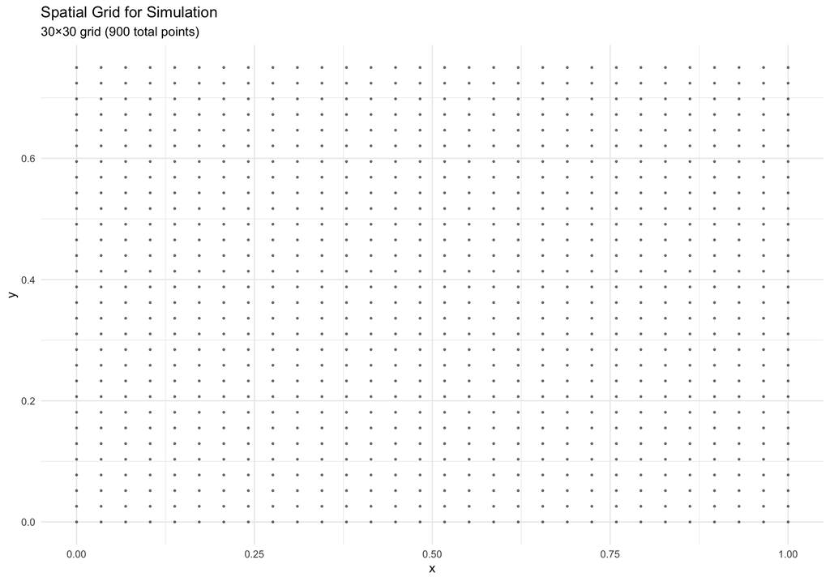

```r
# Create a regular grid of coordinates
coords <- expand.grid(
  x = seq(0, x_max, length.out = nx),
  y = seq(0, y_max, length.out = ny)
)

# Normalize coordinates to [0,1] range
coords <- coords / max(x_max, y_max)
c_mat <- as.matrix(coords)

# Calculate distance matrix between all coordinates
d_coords <- as.matrix(dist(c_mat))

# Visualize the spatial grid
ggplot(coords, aes(x = x, y = y)) +
  geom_point(size = 0.5, alpha = 0.5) +
  theme_minimal() +
  labs(
    title = "Spatial Grid for Simulation",
    subtitle = paste0(nx, "×", ny, " grid (", n, " total points)")
  )
```

## Generate Latent Spatial Fields

Now we’ll generate the latent spatial fields using Gaussian processes with different spatial decay parameters:

```r
# Sample decay parameters for each latent factor
philist <- runif(actual_k, phi_range[1], phi_range[2])
print(paste("Spatial decay parameters (phi):", paste(round(philist, 2), collapse = ", ")))
```

```
#> [1] "Spatial decay parameters (phi): 1.59, 1.45, 2.41"
```

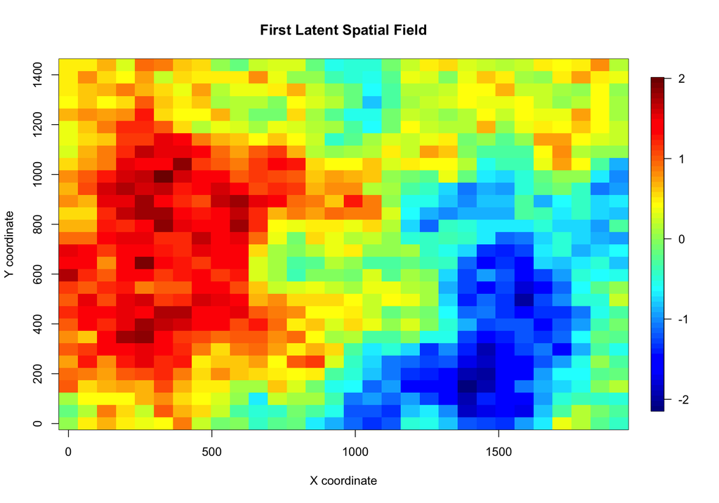

```r
# Create Cholesky factors of the covariance matrices
# Each latent factor has its own spatial correlation structure
LClist <- 1:actual_k %>% lapply(\(i) t(chol(
  exp(- philist[i] * d_coords)
)))

# Generate latent spatial fields for multiple images
VV <- lapply(1:num_images, \(j) {
  # For each image, generate 'actual_k' latent spatial fields
  wlist <- lapply(1:actual_k, \(i) LClist[[i]] %*% rnorm(n))

  # Combine all latent fields into a matrix
  do.call(cbind, wlist)
})

# Visualize first latent field from the first image
if (requireNamespace("fields", quietly = TRUE)) {
  fields::image.plot(
    seq(0, x_max, length.out = nx),
    seq(0, y_max, length.out = ny),
    matrix(VV[[1]][,1], nrow = ny, ncol = nx),
    main = "First Latent Spatial Field",
    xlab = "X coordinate",
    ylab = "Y coordinate"
  )
}
```

## Generate Factor Loadings

Now we’ll create factor loadings to link the latent fields to the observed data:

```r
# Generate factor loadings matrix
Lambda <- matrix(0, q, actual_k)
diag(Lambda) <- runif(actual_k, 0.5, 1)  # Strong diagonal loadings
Lambda[lower.tri(Lambda)] <- runif(sum(lower.tri(Lambda)), -0.7, 0.7)  # Off-diagonal loadings

# Display the factor loadings matrix
print("Factor loadings matrix (Lambda):")
```

```
#> [1] "Factor loadings matrix (Lambda):"
```

```r
print(round(Lambda, 2))
```

```
#>       [,1] [,2] [,3]
#> [1,]  0.56 0.00 0.00
#> [2,] -0.02 0.75 0.00
#> [3,] -0.67 0.07 0.66
#> [4,] -0.69 0.29 0.18
```

```r
# Create covariate matrix (intercept only in this example)
Beta <- matrix(rep(mu, p*q), ncol = q)
print("Beta coefficient matrix:")
```

```
#> [1] "Beta coefficient matrix:"
```

```r
print(round(Beta, 2))
```

```
#>      [,1] [,2] [,3] [,4]
#> [1,]   -1   -1   -1   -1
```

```r
# Create design matrices (just intercept)
x_list <- lapply(1:num_images, \(i) {
  matrix(1, nrow = n, ncol = p)
})
```

## Generate Response Data

Finally, we’ll generate the observed count data (Poisson responses) based on the latent fields:

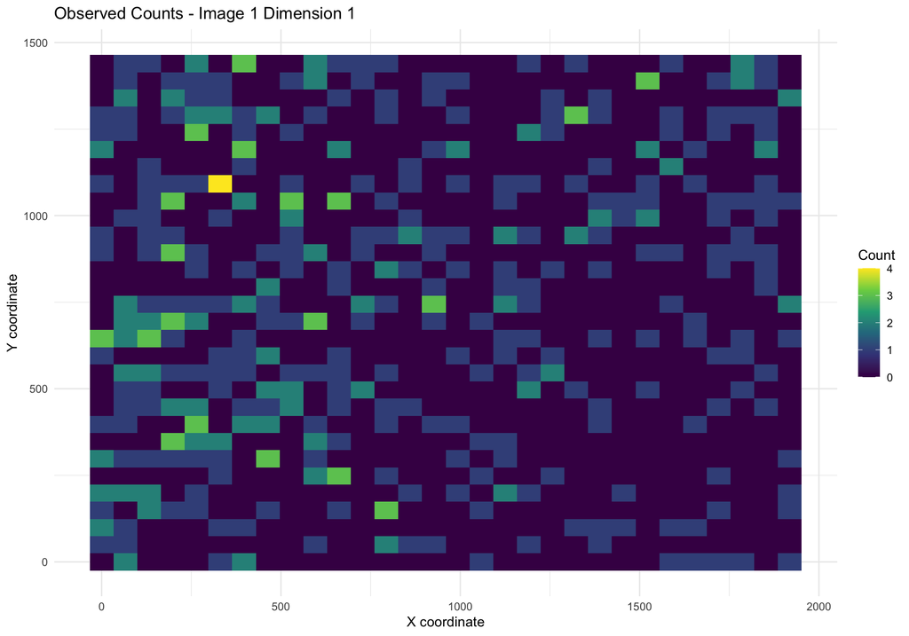

```r
# Combine latent spatial fields with factor loadings to create intensity surfaces
WW <- lapply(1:num_images, \(i) {
  mat <- VV[[i]] %*% t(Lambda) + x_list[[i]] %*% Beta
  mat
})

# Generate Poisson counts based on the intensity
y_list <- lapply(WW, \(ww) {
  matrix(rpois(nrow(ww) * ncol(ww), exp(ww)), nrow = nrow(ww), ncol = ncol(ww))
})

# Visualize the first response dimension from the first image
# Create a simple function to plot the response
plot_y <- function(y, coords, dimension = 1, image_num = 1) {
  data <- data.frame(
    x = coords$x * max(x_max, y_max),
    y = coords$y * max(x_max, y_max),
    count = y[[ image_num]][, dimension]
  )

  ggplot(data, aes(x = x, y = y, fill = count)) +
    geom_tile() +
    scale_fill_viridis_c() +
    theme_minimal() +
    labs(
      title = paste("Observed Counts - Image", image_num, "Dimension", dimension),
      x = "X coordinate",
      y = "Y coordinate",
      fill = "Count"
    )
}

# Plot the first dimension of the first image
plot_y(y_list, coords)
```

# Run BIPPS Models

Now we’ll run the BIPPS model for each of our trial k values. We’ll use the same dataset for all models but vary the number of latent factors:

```r
# Function to run BIPPS for a specific k value
run_bipps_with_k <- function(trial_k) {
  cat("Running BIPPS with k =", trial_k, "\n")

  # Run BIPPS
  out <- multi_bipps(
    y_list = y_list,
    x_list = x_list,
    coords = coords,
    k = trial_k,
    family = "poisson",
    block_size = block_size,
    n_samples = n_samples,
    n_burn = n_burnin,
    n_thin = n_thin,
    n_threads = n_threads,
    starting = starting,
    prior = prior,
    settings = list(adapting = TRUE, saving = TRUE, ps = TRUE, low_mem = TRUE),
    verbose = 10,
    debug = list(
      sample_beta = TRUE,
      sample_tausq = FALSE,
      sample_theta = sample_theta,
      sample_w = TRUE,
      sample_lambda = TRUE,
      verbose = FALSE,
      debug = FALSE
    )
  )

  return(out)
}

# Run BIPPS for each trial k
results <- list()
for (k in trial_ks) {
  results[[as.character(k)]] <- run_bipps_with_k(k)
}
```

```
#> Running BIPPS with k = 2
#> Bayesian Meshed GP regression model fit via Markov chain Monte Carlo
#> Sending to MCMC.
#> 10.2% elapsed:  5752ms (+ 5601ms). ETR: 55.70s.
#>   theta: Metrop. acceptance 30.50%, average 59.80%
#>   theta = 7.944 0.430 9.075 36.181
#>   lambda = 2.140 -0.089 -2.588 -2.758 0.000 1.307 0.995 1.472
#>
#> 20.3% elapsed: 11513ms (+ 5760ms). ETR: 49.72s.
#>   theta: Metrop. acceptance 41.50%, average 42.36%
#>   theta = 3.676 0.284 9.832 52.005
#>   lambda = 1.345 -0.186 -1.905 -1.742 0.000 1.063 -0.296 0.803
#>
#> 30.4% elapsed: 16997ms (+ 5484ms). ETR: 42.81s.
#>   theta: Metrop. acceptance 20.50%, average 33.55%
#>   theta = 2.698 0.238 6.045 180.964
#>   lambda = 1.067 0.006 -1.595 -1.482 0.000 1.356 -0.294 0.414
#>
#> 40.5% elapsed: 22451ms (+ 5453ms). ETR: 36.28s.
#>   theta: Metrop. acceptance 16.50%, average 29.63%
#>   theta = 1.758 0.598 2.667 573.894
#>   lambda = 0.907 -0.139 -1.328 -1.297 0.000 0.969 -0.581 0.105
#>
#> 50.6% elapsed: 27849ms (+ 5397ms). ETR: 29.91s.
#>   theta: Metrop. acceptance 22.00%, average 28.85%
#>   theta = 1.092 0.225 3.390 738.196
#>   lambda = 0.864 -0.265 -1.281 -1.253 0.000 0.630 -0.602 0.015
#>
#> 60.7% elapsed: 31750ms (+ 3901ms). ETR: 22.61s.
#>   theta: Metrop. acceptance 31.50%, average 30.31%
#>   theta = 0.708 0.422 1.972 484.726
#>   lambda = 0.779 -0.133 -1.291 -1.270 0.000 0.727 -0.473 -0.056
#>
#> 70.8% elapsed: 35228ms (+ 3478ms). ETR: 15.98s.
#>   theta: Metrop. acceptance 31.50%, average 29.52%
#>   theta = 0.560 0.394 3.039 269.198
#>   lambda = 0.777 -0.158 -1.241 -1.086 0.000 0.672 -0.796 -0.067
#>
#> 80.9% elapsed: 38630ms (+ 3401ms). ETR: 10.03s.
#>   theta: Metrop. acceptance 29.00%, average 30.04%
```

[output cut: 92 more lines]

```
#>   theta: Metrop. acceptance 31.00%, average 33.76%
#>   theta = 0.877 0.349 2.130 351.544 0.481 4.979 6.022 237.348
#>   lambda = 0.814 -0.274 -0.801 -1.054 0.000 0.680 -0.046 0.251 0.000 0.000
#>
#> 80.9% elapsed: 73329ms (+ 5977ms). ETR: 19.04s.
#>   theta: Metrop. acceptance 29.50%, average 33.13%
#>   theta = 1.071 0.733 2.138 63.606 0.722 17.809 6.372 686.868
#>   lambda = 0.699 -0.288 -0.774 -0.987 0.000 0.893 -0.246 0.076 0.000 0.000
#>
#> 91.0% elapsed: 79196ms (+ 5866ms). ETR: 8.62s.
#>   theta: Metrop. acceptance 27.50%, average 32.31%
#>   theta = 0.639 0.370 3.957 30.121 1.086 15.985 8.304 484.019
#>   lambda = 0.700 -0.263 -0.733 -0.933 0.000 0.844 -0.105 0.287 0.000 0.000
#>
#> MCMC done [84.09s]
```

```r
# Save results
saveRDS(results, "output/bipps_varying_k_results.rds")
```